# Reproducible Research: Peer Assessment 1

lz  
2018-11-03

## Loading and preprocessing the data

1. Load the data
2. Transform the “date”" columns into date format

```r
activity <- read.csv('activity.csv', header = T)
activity$date <- as.Date(as.character(activity$date), '%Y-%m-%d')
```

## What is mean total number of steps taken per day?

1. Calculate the total number of steps taken per day
2. Make a histogram of the total number of steps taken each day

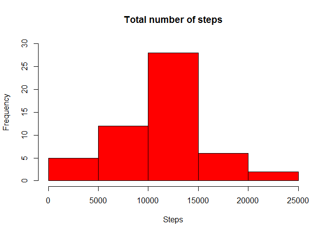

```r
library(dplyr)
daytotal <- activity %>% group_by(date) %>% summarise(total.steps = sum(steps))
hist(daytotal$total.steps, ylim = c(0,30), col = 'red',xlab = 'Steps', main = 'Total number of steps')
```

3. Calculate the mean and median of the total number of steps taken per day.
- According to the following results, the mean of the total number of steps taken per day is **10766.19**, and the median is **10765**.

```r
mean(daytotal$total.steps, na.rm = T)
```

```
## [1] 10766.19
```

```r
median(daytotal$total.steps, na.rm = T)
```

```
## [1] 10765
```

## What is the average daily activity pattern?

1. Make a time series plot of the 5-minute interval (x-axis) and the average number of steps taken, averaged across all days (y-axis)

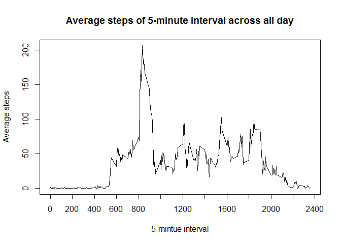

```r
intervaldata <- activity %>% group_by(interval) %>% summarise(ave.steps = mean(steps, na.rm = T))
plot(intervaldata$interval, intervaldata$ave.steps, type = 'l',ann = F, xaxt = 'n')
title(main = 'Average steps of 5-minute interval across all day',
      ylab = 'Average steps', xlab = '5-mintue interval')
axis(side = 1, at = seq(0,2400,200))
```

2. Which 5-minute interval, on average across all the days in the dataset, contains the maximum number of steps?
- According to the following result, the interval **“835”** contains the max number of steps.

```r
intervaldata$interval[which.max(intervaldata$ave.steps)]
```

```
## [1] 835
```